# **Projet 1 : Prédiction des ventes pour Black-Friday**

KEITA Alhousseni - Data Scientist

https://keitaalhousseni.github.io/

13 août 2020

### *Objectifs du projet*

Une société de vente au détail «ABC Private Limited » souhaite comprendre le comportement d’achat des clients (en particulier, le montant de l’achat) par rapport à divers produits de différentes catégories. Ils ont partagé le résumé des achats de divers produits.

L’objetif est de construire un modèle pour prédire le montant d’achat des clients par rapport à divers produits, ce qui aidera à créer une offre personnalisée pour les clients par rapport à différents produits.

### *Installation des packages*

```r
install.packages('data.table')
install.packages('dplyr')
install.packages('ggplot2')
install.packages('GGally')
install.packages('corrplot')
install.packages('xgboost')
install.packages('DiagrammeR')
install.packages("rsample")
install.packages("caret")
install.packages('cowplot')
install.packages('Hmisc')
install.packages("ade4")
install.packages("gam")
install.packages('knitr')
install.packages('kableExtra')
```

### *Importation des library*

```r
library(data.table)
library(dplyr)
library(ggplot2)
library(GGally)
library(corrplot)
library(xgboost)
library(DiagrammeR)
library(rsample)
library(caret)
library(cowplot)
library(Hmisc)
library(ade4)
library(gam)
library(knitr)
library(kableExtra)
```

### *Importation des données*

```r
BFTrain <- fread('https://raw.githubusercontent.com/armelsoubeiga/sales_prediction_Machine_Learning/master/Projet_1_Black-Friday/data/train_bf.csv',
                 sep = ",", header = TRUE)
dim(BFTrain)
```

```
## [1] 550068     12
```

Le jeu de données comprend `550068` lignes et `12` variables.

### *Verification noms des colonnes*

```r
names(BFTrain)
```

```
##  [1] "User_ID"                    "Product_ID"
##  [3] "Gender"                     "Age"
##  [5] "Occupation"                 "City_Category"
##  [7] "Stay_In_Current_City_Years" "Marital_Status"
##  [9] "Product_Category_1"         "Product_Category_2"
## [11] "Product_Category_3"         "Purchase"
```

### *Verification types et détails des colonnes*

```r
str(BFTrain)
```

```
## Classes 'data.table' and 'data.frame':   550068 obs. of  12 variables:
##  $ User_ID                   : int  1000001 1000001 1000001 1000001 1000002 1000003 1000004 1000004 1000004 1000005 ...
##  $ Product_ID                : chr  "P00069042" "P00248942" "P00087842" "P00085442" ...
##  $ Gender                    : chr  "F" "F" "F" "F" ...
##  $ Age                       : chr  "0-17" "0-17" "0-17" "0-17" ...
##  $ Occupation                : int  10 10 10 10 16 15 7 7 7 20 ...
##  $ City_Category             : chr  "A" "A" "A" "A" ...
##  $ Stay_In_Current_City_Years: chr  "2" "2" "2" "2" ...
##  $ Marital_Status            : int  0 0 0 0 0 0 1 1 1 1 ...
##  $ Product_Category_1        : int  3 1 12 12 8 1 1 1 1 8 ...
##  $ Product_Category_2        : int  NA 6 NA 14 NA 2 8 15 16 NA ...
##  $ Product_Category_3        : int  NA 14 NA NA NA NA 17 NA NA NA ...
##  $ Purchase                  : int  8370 15200 1422 1057 7969 15227 19215 15854 15686 7871 ...
##  - attr(*, ".internal.selfref")=<externalptr>
```

### *Analyse Exploratoire des Données (EDA)*

#### Analyse exploratoire Univarié

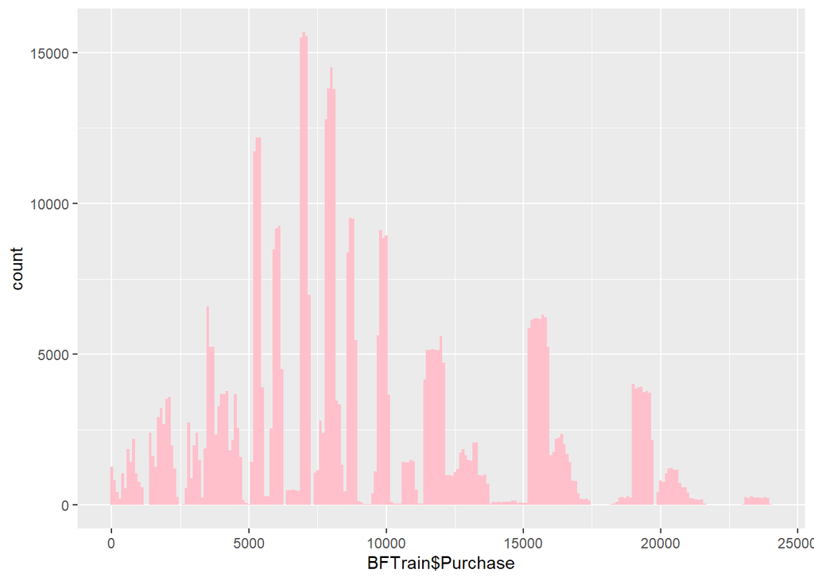

```r
ggplot(BFTrain) + geom_histogram(aes(BFTrain$Purchase), binwidth = 100 ,
                                 fill = "pink")
```

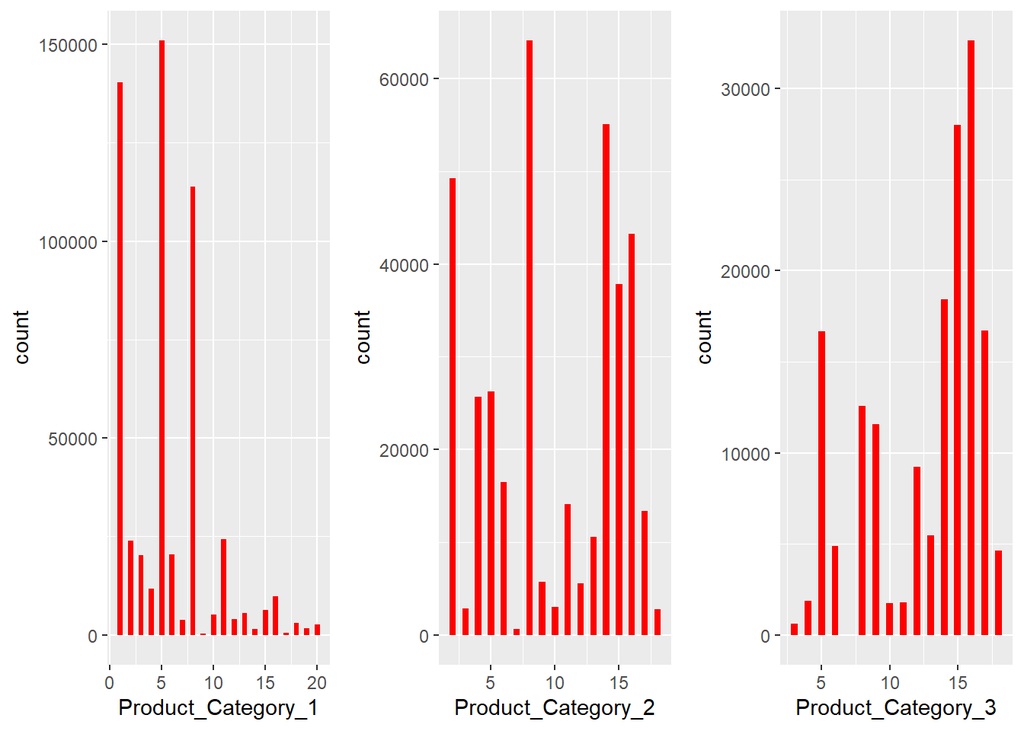

```r
p1 = ggplot(BFTrain)+ geom_histogram(aes(Product_Category_1), binwidth=0.5,fill="red")
p2 = ggplot(BFTrain)+ geom_histogram(aes(Product_Category_2), binwidth=0.5,fill="red")
p3 = ggplot(BFTrain)+ geom_histogram(aes(Product_Category_3), binwidth=0.5,fill="red")
plot_grid(p1,p2,p3,nrow = 1)
```

#### Analyse exploratoire Bivarié

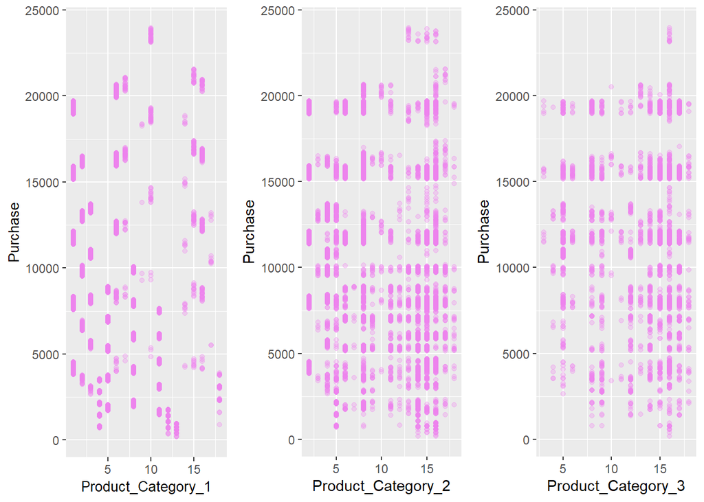

```r
BFTrainS <- BFTrain[1:10000,]
pp1 <- ggplot(BFTrainS)+geom_point(aes(Product_Category_1 ,Purchase),color="violet",alpha=0.3)+
  theme(axis.title = element_text(size = 10))

pp2 <-ggplot(BFTrainS)+geom_point(aes(Product_Category_2 ,Purchase),color="violet",alpha =0.3)

pp3 <-ggplot(BFTrainS)+geom_point(aes(Product_Category_3 ,Purchase),color="violet",alpha=0.3)

plot_grid(pp1,pp2,pp3,nrow = 1)
```

#### Analyse exploratoire multivarié

```r
#Data selection
d <-  BFTrain[, c("Gender","Age", "Occupation", "City_Category", "Stay_In_Current_City_Years","Marital_Status" ,  "Product_Category_1", "Product_Category_2", "Product_Category_3","Purchase")]
d <- mutate_if(d, is.character, as.factor)
d <- na.gam.replace(d)
```

```r
# Analyse factorielle des données mixte
afdm <- dudi.mix(d, scannf = FALSE, nf = 5)
```

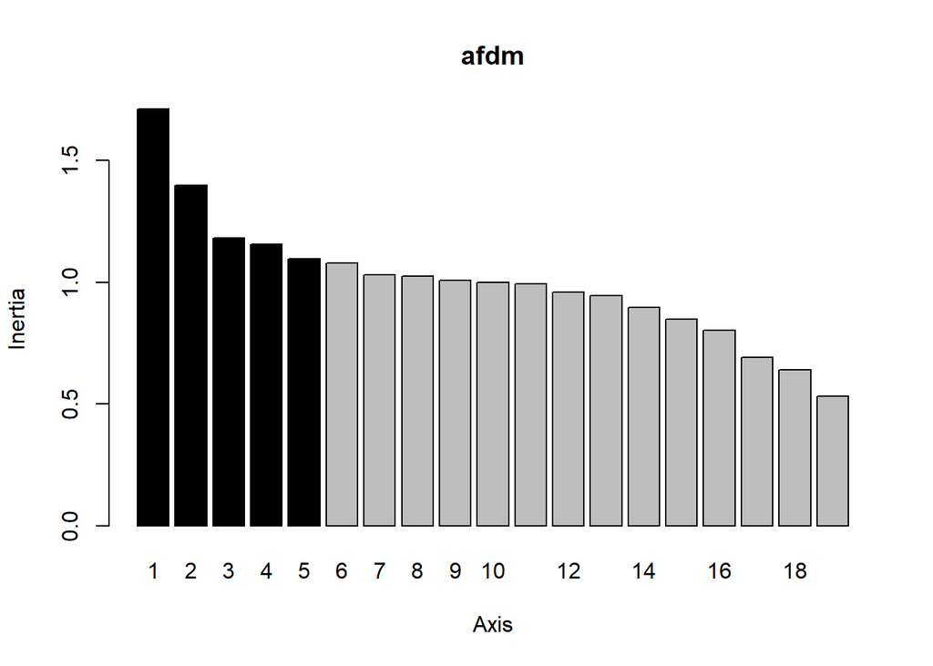

```r
# Le graphique des valeus propres
screeplot(afdm)
```

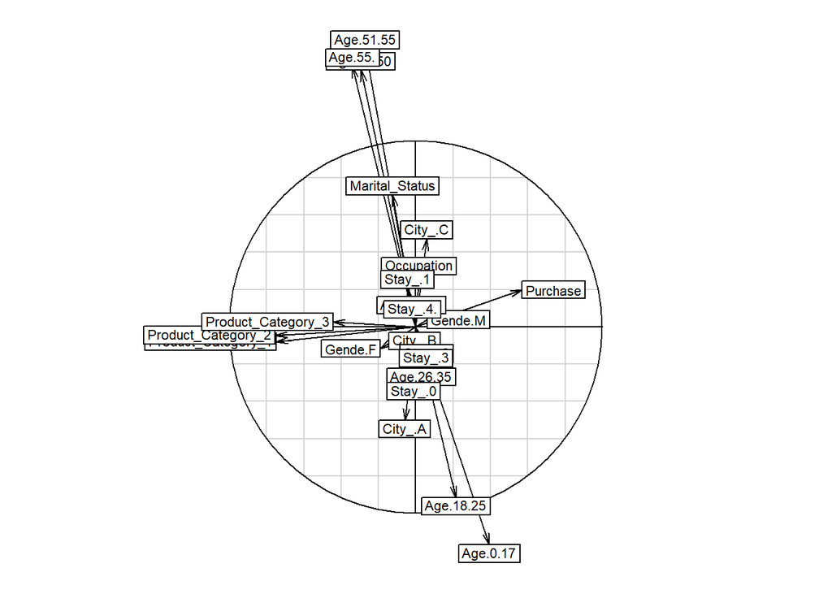

```r
# Cercle de correlation
s.corcircle(afdm$co, 1, 2, clabel = 0.7)
```

```r
# Nuage de points en fonction du sexe
s.class(afdm$li, d$Gender, col = brewer.pal(4, "Set1"))
```

[figure not shown]

#### Corrélation des variable

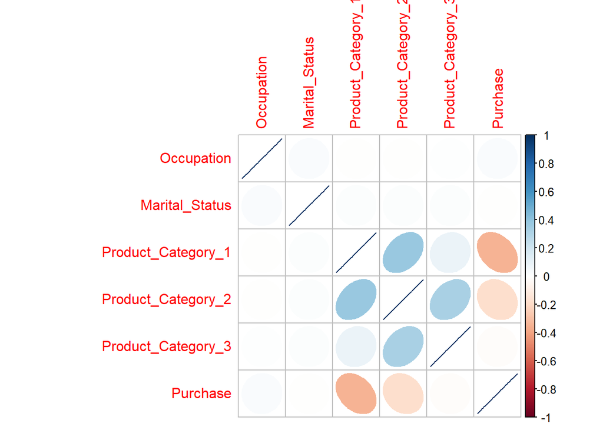

```r
c <-  d[, c("Occupation","Marital_Status","Product_Category_1", "Product_Category_2","Product_Category_3","Purchase")]
corrplot(cor(c), method = "ellipse")
```

```r
BFTrain$User_ID <- as.factor(BFTrain$User_ID)
BFTrain$Product_ID <- as.factor(BFTrain$Product_ID)
BFTrain$Marital_Status <- as.factor(ifelse(BFTrain$Marital_Status==1, 'Married', 'Single'))
BFTrain$Age <-  as.factor(BFTrain$Age)
BFTrain$Gender <- as.factor(ifelse(BFTrain$Gender=='M','Male', 'Female'))
BFTrain$Occupation <-  as.factor(BFTrain$Occupation)
BFTrain$City_Category <- as.factor(BFTrain$City_Category)
BFTrain$Stay_In_Current_City_Years <- as.factor(BFTrain$Stay_In_Current_City_Years)
```

```r
#Selection des valeurs unique
BF_dist <- distinct(BFTrain, User_ID, Age, Gender, Marital_Status, Occupation, City_Category, Stay_In_Current_City_Years, Product_Category_1,
                    Product_Category_2,Product_Category_3)
kable(head(BF_dist,3))%>%
  kable_styling(bootstrap_options = "striped", full_width = F)
```

| User_ID | Gender | Age | Occupation | City_Category | Stay_In_Current_City_Years | Marital_Status | Product_Category_1 | Product_Category_2 | Product_Category_3 |
| --- | --- | --- | --- | --- | --- | --- | --- | --- | --- |
| 1000001 | Female | 0-17 | 10 | A | 2 | Single | 3 | NA | NA |
| 1000001 | Female | 0-17 | 10 | A | 2 | Single | 1 | 6 | 14 |
| 1000001 | Female | 0-17 | 10 | A | 2 | Single | 12 | NA | NA |

### *Feature Engineering*

#### Création de la VAR représentant le nombre de chaque utilisateur

```r
user_count <- plyr::ddply(BFTrain, "User_ID", nrow)
names(user_count)[2] <- "User_Count"
BFTrain <- merge(BFTrain, user_count, by="User_ID")
```

#### Création de la VAR représentant le nombre de chaque ptoduit

```r
product_count <- plyr::ddply(BFTrain,"Product_ID",nrow)
names(product_count)[2] <- "Product_Count"
BFTrain <- merge(BFTrain, product_count, by="Product_ID")
```

#### Création variable achat moyen de chaque produit

```r
product_mean <- plyr::ddply(BFTrain, "Product_ID", summarise, Product_Mean =mean(Purchase))
BFTrain <- merge(BFTrain, product_mean, by="Product_ID")
```

### *XGBoost, pourquoi c’est génial ?*

- **1. Parallèlisation:** par défaut, l’algorithme utilise tous les cœurs du microprocesseur de la machine, d’où un sérieux gain de temps.
- **2. Régularisation:** XGBoost comprend une régularisation, ce qui permet d’éviter le surajustement (over-fitting). Ainsi, on a plus de chances d’obtenir un modèle qui performe bien sur échantillon d’apprentissage, sur échantillon de test, et aussi sur de nouvelles données. On dit qu’il est généralisable.
- **3. Non linéarité:** Etant basé sur des arbres de décision, XGBoost capture tous types de liaisons entre données, y compris non linéaires.
- **4.Validation croisée:** intégrée dans l’algorithme, il n’y a pas besoin de la programmer par ailleurs.
- **5. Données manquantes:** gérées nativement par l’algorithme. Il est capable de capturer et comprendre leur structure, dans le cas où elles ne sont pas dues au pur hasard.
- **6. Flexibilité:** possibilité de faire de la régression, de la classification et du classement (ranking). De plus, il est possible de définir soi-même une fonction objectif à optimiser lors de l’entraînement du modèle. Très utile en classification quand on veut par exemple donner plus de poids aux faux négatifs qu’aux faux positifs ou l’inverse. Cette fonctionnalité est très utile dans la détection de la fraude et dans le dépistage de maladies graves.
- **7. Disponibilité & scalabilité:** XGBoost est utilisable avec la majorité des plateformes (Windows, Linux, macOS) et des langages (C++, Java, Python, Julia). Il peut aussi tourner de manière distribuée sur Apache Hadoop, Spark, et Flink, ce qui ouvre la porte au traitement de données véritablement massives (allez, on va dire un gros mot : “big data”).
- **8. Save & Reload:** Entraîner & sauvegarder son modèle & sa matrice de données avec Python. Les recharger (soi-même ou quelqu’un d’autre) plus tard avec R pour usage de prédiction immédiat. What Else ?
- **9. Elagage des arbres (tree-pruning):** Consiste à supprimer les branches (parties terminales) d’arbres de décision peu utiles pour la prédiction. Ainsi, on simplifie le modèle final, et on gagne en performances prédictives (généralisation).

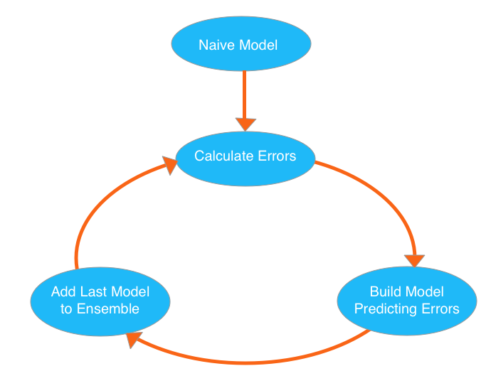

### *Séparation en jeu de données d’entrainement et de test*

```r
data_split <- initial_split(BFTrain, prop = 0.75)
data_train <- training(data_split)
data_test <- testing(data_split)
```

Nous obtenons un jeu de données d’entrainement de `412551` de lignes et pour les données de test `137517` de lignes.

### *Modèle de prédiction*

#### Selection des variable d’interrêts

```r
y_train <- data_train$Purchase
y_test <- data_test$Purchase

x_train <- subset(data_train, select = -c(Purchase, Product_ID))
x_test <- subset(data_test, select = -c(Purchase, Product_ID))
```

#### Transformation des données en entrée xgbs

```r
x_train <-  as.matrix(x_train)
y_train <- as.numeric(y_train)
mode(x_train) <- 'double'

x_test <-  as.matrix(x_test)
y_test <- as.numeric(y_test)
mode(x_test) <- 'double'
```

```r
model_xgb <- xgboost(data = x_train,
                     label = y_train,
                     cv = 5,
                     booster = "gbtree",
                     objective = "reg:linear",
                     nrounds = 100,
                     max.depth = 10,
                     eta = 0.1,
                     colsample_bytree = 0.5,
                     set.seed = 235,
                     eval_metric = "rmse",
                     importance = 1)
```

[output not shown]

### *Prédiction sur les données de TEST*

```r
pred <- predict(model_xgb,x_test)
```

### *Evaluation du modèle : précision et taux d’erreur*

```r
actuals_preds <- data.frame(cbind(actuals=y_test, predicteds=pred))
cor(actuals_preds)[1,2]
```

```
## [1] 0.8622238
```

Une simple corrélation entre les valeurs réelles et prédites peut être utilisée comme une forme de mesure de précision.

La corrélation montre une valeur élevée de `0.86` %, ce qui signifie que les valeurs réelles et les valeurs prévues ont un mouvement directionnel similaire.

Les valeurs réelles et celles prévues semblent très proches les unes des autres. Une bonne métrique pour voir à quel point ils sont proches est la précision min-max , qui considère la moyenne entre la prédiction minimale et maximale.

```r
min_max_accuracy <- mean(apply(actuals_preds, 1, min) / apply(actuals_preds, 1, max))
print(min_max_accuracy)
```

```
## [1] 0.8039115
```

Le résultat de `0.8039115`est une valeur élevée, et cela signifie que la précision est très bonne. *Remarque*: idéalement, le résultat de 1 correspond à une prédiction presque parfaite

```r
postResample(pred, y_test)
```

```
##         RMSE     Rsquared          MAE
## 2545.7958705    0.7434299 1878.6364462
```

### *Importance des variables*

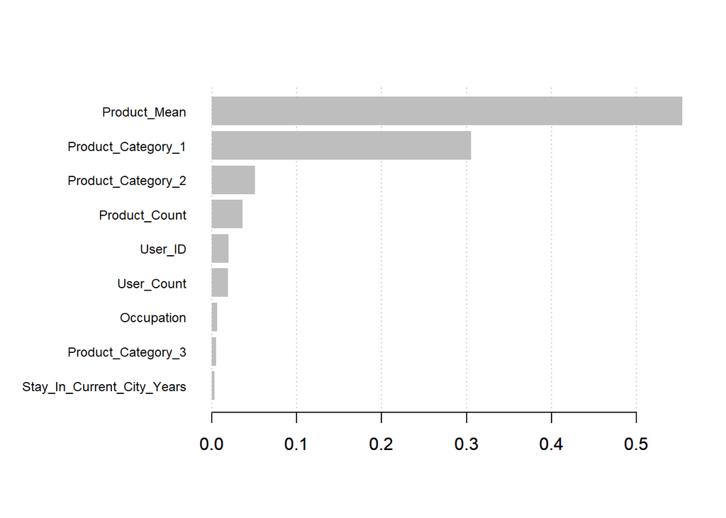

```r
mat <- xgb.importance (feature_names = colnames(x_train),model = model_xgb)
xgb.plot.importance(importance_matrix = mat)
```

### Abre de décision de l’importances des variables

```r
xgb.plot.tree(model = model_xgb)
```

[output not shown]

#### Enregistrer et load le modèle

```r
# Enregistrement
xgb.save(model_xgb, "xgboost.model")

#Import du modèle
model_xgb <- xgb.load("xgboost.model")

#Prediction
prediction <- predict(model_xgb, new_data)
```

### *References*

https://xgboost.readthedocs.io/en/latest/index.html

https://cran.r-project.org/web/packages/xgboost/vignettes/xgboostPresentation.html